# Exploratory Data Analysis

STOR 320.(01) Group 6 (Ex: STOR 320.01 Group 12)

July 14, 2020

# Creator: Noah Wessels

### Q1: How much do one’s grades influence post-graduate life (i.e. placement status, salary)?

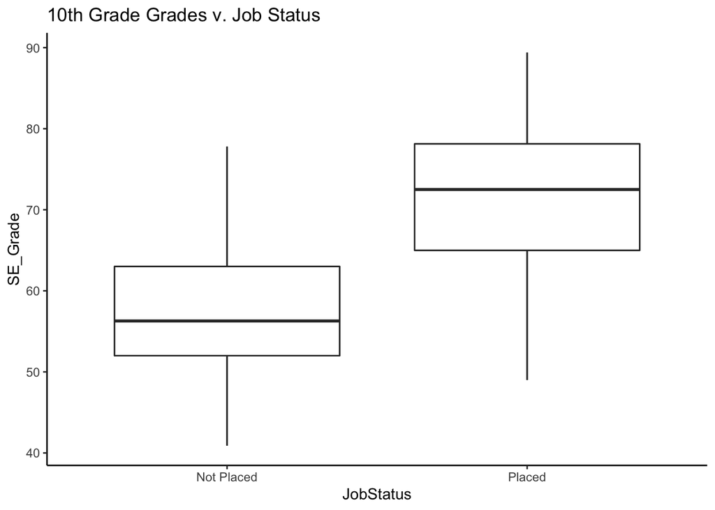

```r
#
Q1D<- select(PlacementData,SE_Grade, HSE_Grade,UG_Grade, MBA_Grade, JobStatus) %>% group_by(JobStatus)
ggplot(Q1D,aes(x=SE_Grade,y=JobStatus))+ geom_boxplot() + coord_flip() + stat_boxplot() + ggtitle("10th Grade Grades v. Job Status") +theme_classic()
```

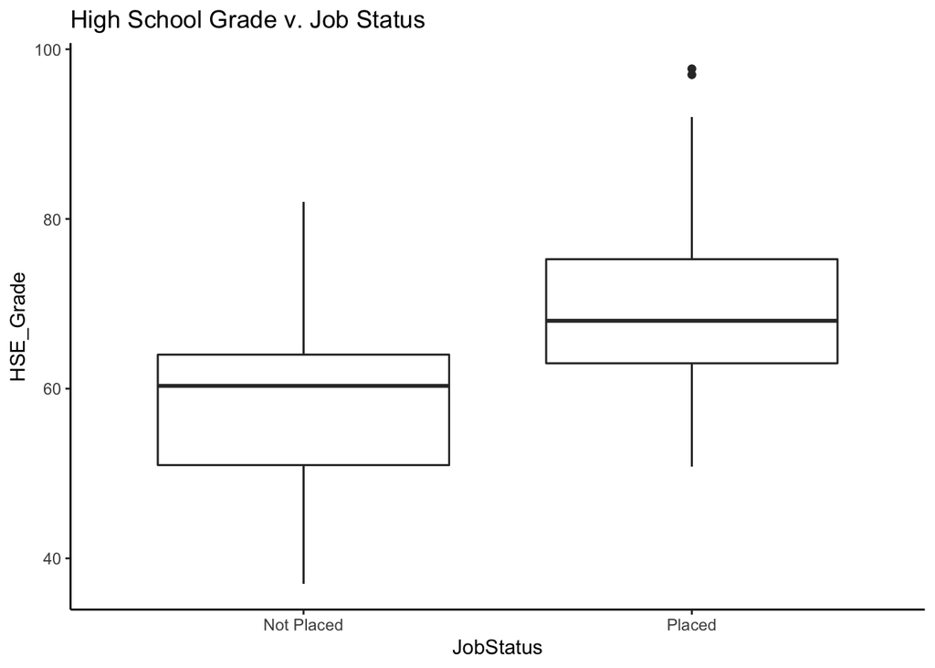

```r
ggplot(Q1D,aes(x=HSE_Grade,y=JobStatus))+ geom_boxplot() + coord_flip() + stat_boxplot() + ggtitle("High School Grade v. Job Status") +theme_classic()
```

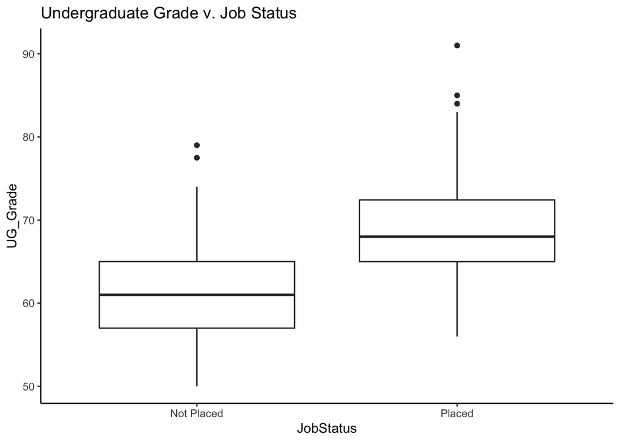

```r
ggplot(Q1D,aes(x=UG_Grade,y=JobStatus))+ geom_boxplot() + coord_flip()+ stat_boxplot() + ggtitle("Undergraduate Grade v. Job Status")+ theme_classic()
```

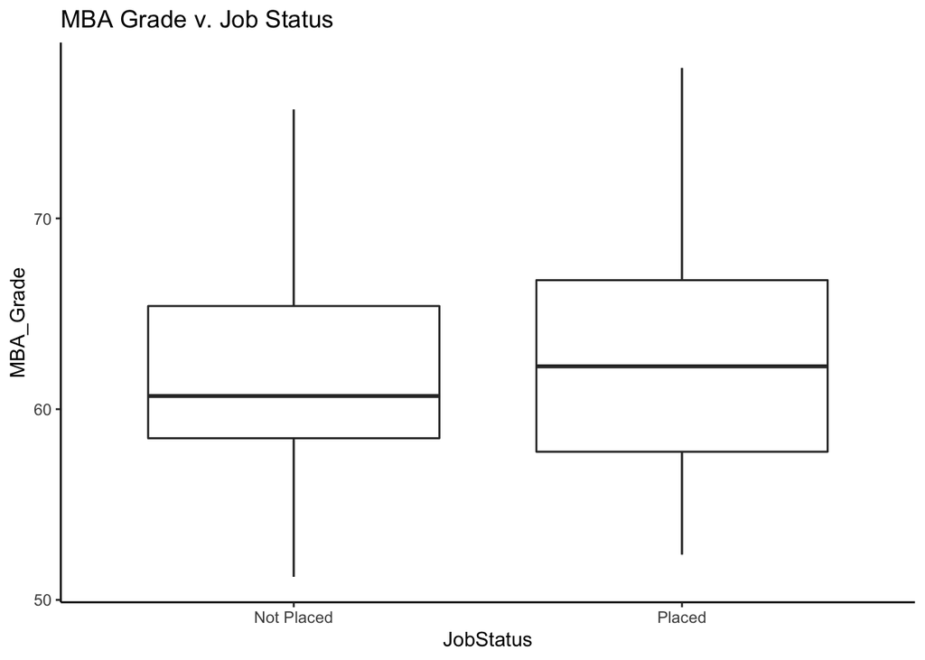

```r
ggplot(Q1D,aes(x=MBA_Grade,y=JobStatus))+ geom_boxplot() + coord_flip() + stat_boxplot() + ggtitle("MBA Grade v. Job Status")+ theme_classic()
```

From the graphs above, I would hypothesize that there is a significant impact of one’s grades in High School as well as their Undergraduate career. There doesn’t look to be much difference in the MBA grade and whether or not a person was placed into a job. In order to discuss the specific magnitudes we will need to account for the impact of each variable within a model with all other exploratory variables that impact Job Placement.

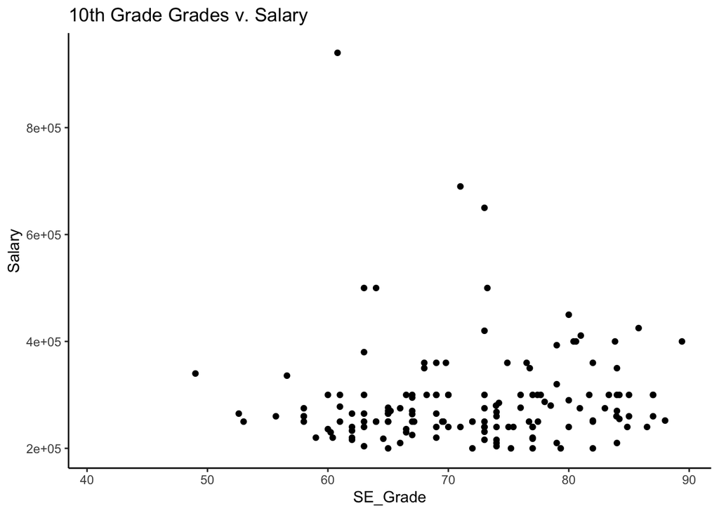

```r
#
Q2D<- select(PlacementData,SE_Grade, HSE_Grade,UG_Grade, MBA_Grade, Salary) %>% group_by(Salary)
ggplot(Q2D,aes(x=SE_Grade,y=Salary))+ geom_point() + ggtitle("10th Grade Grades v. Salary") + theme_classic()
```

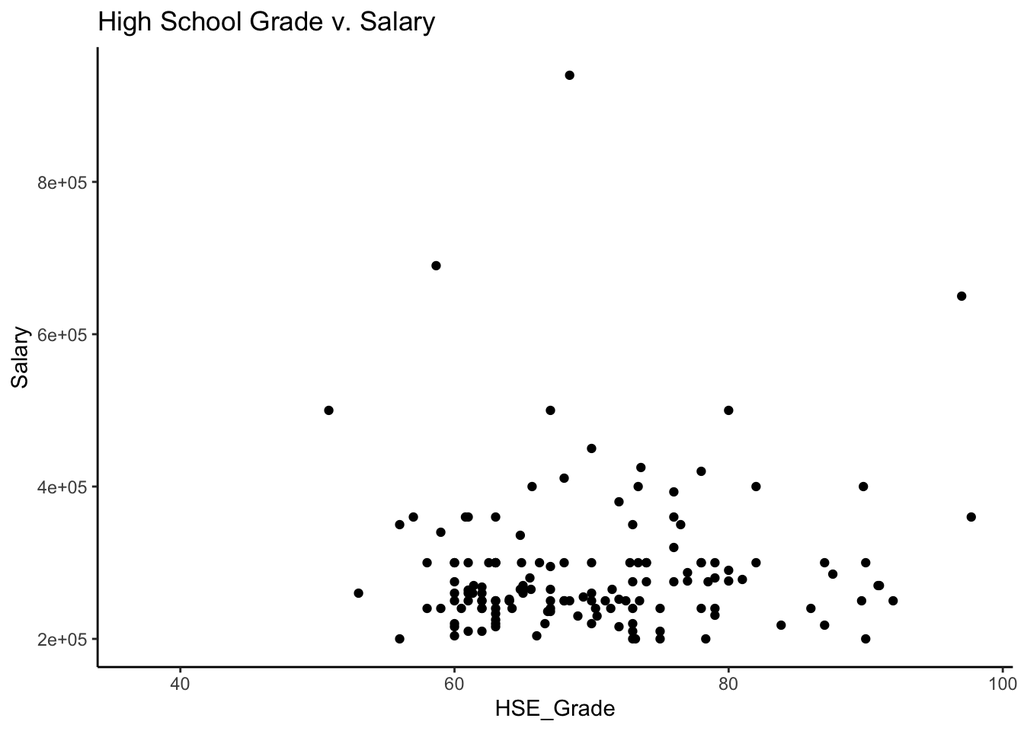

```r
ggplot(Q2D,aes(x=HSE_Grade,y=Salary))+ geom_point() + ggtitle("High School Grade v. Salary") + theme_classic()
```

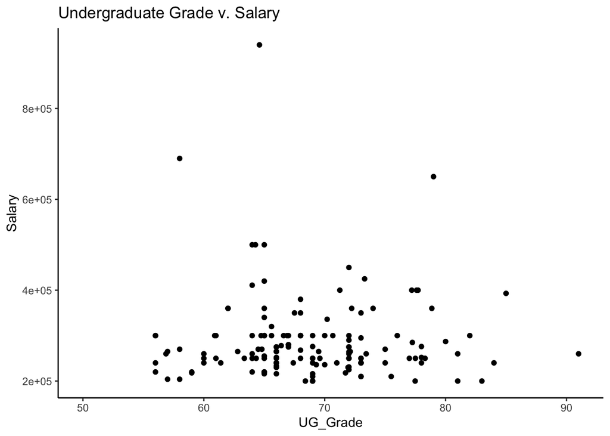

```r
ggplot(Q2D,aes(x=UG_Grade,y=Salary))+ geom_point() + ggtitle("Undergraduate Grade v. Salary")+ theme_classic()
```

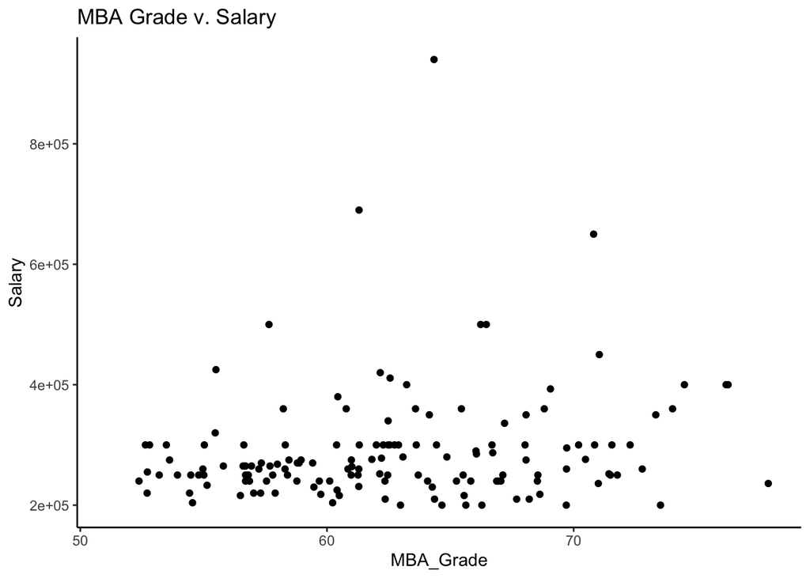

```r
ggplot(Q2D,aes(x=MBA_Grade,y=Salary))+ geom_point() + ggtitle("MBA Grade v. Salary")+ theme_classic()
```

```r
summarize(Q2D, SEmean=mean(SE_Grade), HSEmean=mean(HSE_Grade), UGmean=mean(UG_Grade), MBAmean=mean(MBA_Grade))
```

```
## # A tibble: 46 x 5
##    Salary SEmean HSEmean UGmean MBAmean
##     <dbl>  <dbl>   <dbl>  <dbl>   <dbl>
##  1 200000   75.1    74.3   74.6    67.1
##  2 204000   68.5    63     57.5    57.4
##  3 210000   75.8    67.8   72.6    65.7
##  4 216000   69.7    65     66.7    60.8
##  5 218000   70.8    85.4   65.4    64.2
##  6 220000   65.5    66.5   61.8    55.9
##  7 225000   67      63     72      60.4
##  8 230000   63.4    69.7   69.0    61.9
##  9 231000   73      79     72      61.3
## 10 233000   62      63     66      55.1
## # … with 36 more rows
```

### Q2: How good of a measure is the employability test of job placement?

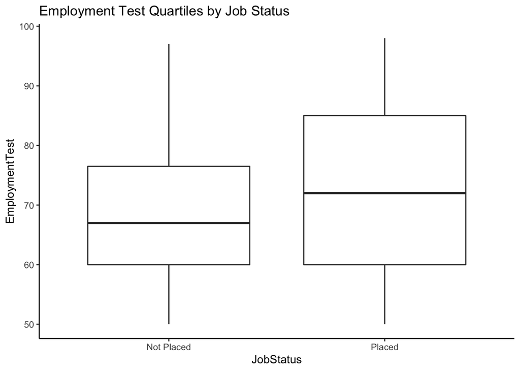

```r
#
ggplot(PlacementData,aes(x=EmploymentTest,y=JobStatus)) + geom_boxplot() + stat_boxplot() + coord_flip() + ggtitle("Employment Test Quartiles by Job Status")+ theme_classic()
```

```r
JobStatus1 <-ifelse(PlacementData$JobStatus=="Placed", 1, 0)
LM1 = lm(JobStatus1~EmploymentTest, data=PlacementData)
summary(LM1)
```

```
##
## Call:
## lm(formula = JobStatus1 ~ EmploymentTest, data = PlacementData)
##
## Residuals:
##     Min      1Q  Median      3Q     Max
## -0.7995 -0.6279  0.2585  0.3366  0.4103
##
## Coefficients:
##                Estimate Std. Error t value Pr(>|t|)
## (Intercept)    0.366562   0.174207   2.104   0.0365 *
## EmploymentTest 0.004463   0.002376   1.878   0.0617 .
## ---
## Signif. codes:  0 '***' 0.001 '**' 0.01 '*' 0.05 '.' 0.1 ' ' 1
##
## Residual standard error: 0.4615 on 213 degrees of freedom
## Multiple R-squared:  0.01629,    Adjusted R-squared:  0.01167
## F-statistic: 3.528 on 1 and 213 DF,  p-value: 0.06172
```

At first glance it looks as though the boxplot would indicate that the better one does on their employment test, the more likely they will be placed into a job. Although, from the bivariate regression we can conclude that the coefficient of the Employment Test in this model is not statistically different from zero at a level of 5%.

# Interpreter: Yunzhou Liu

### Q1: Is there a correlation between employability test and salary?

```r
#
# Need to first drop the NAs
# Test for correlation
wo.NA = PlacementData %>% filter(!is.na(EmploymentTest) & !is.na(Salary))
cor(wo.NA$EmploymentTest, wo.NA$Salary)
```

```
## [1] 0.1783073
```

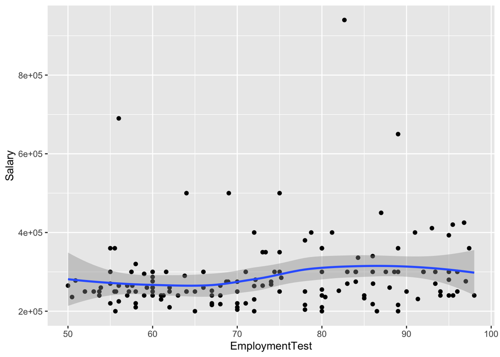

```r
wo.NA %>% ggplot(mapping=aes(x=EmploymentTest, y=Salary))+geom_point()+geom_smooth()
```

The `cor` output gives us the correlation between `employability test` and `salary`, which is 0.1783073. And thus we can see that there is a **weak positive correlation** between `employability test` and `salary`.

### Q2: Are there any significant differences of salaries between different fields of undergraduate research?

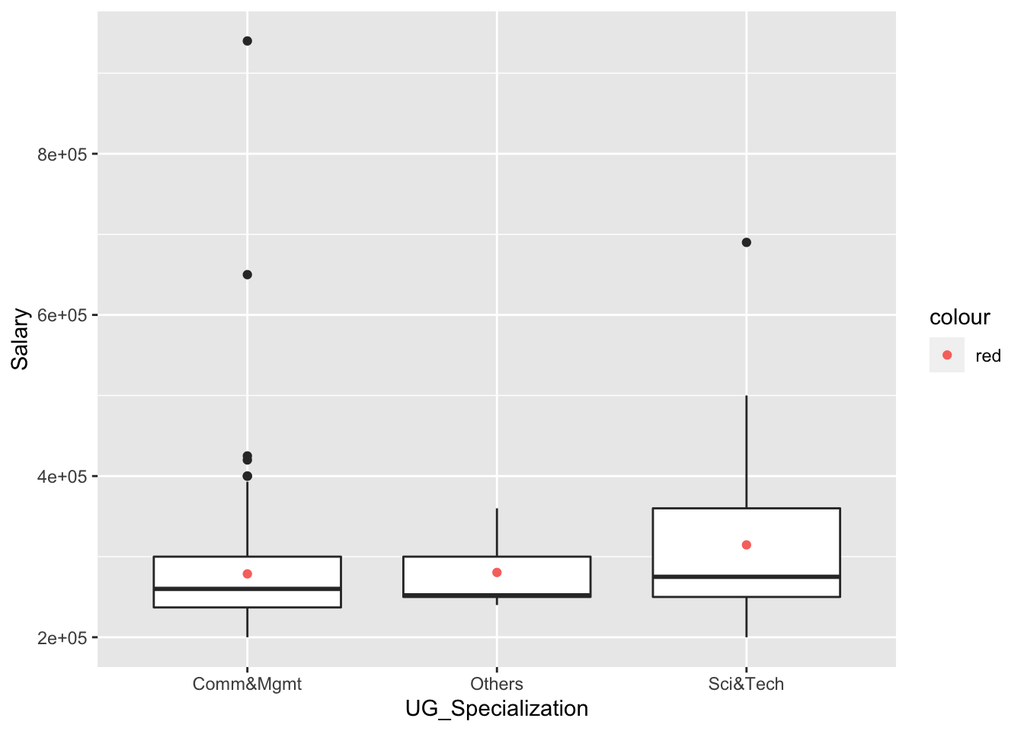

```r
wo.NA2 = PlacementData %>% filter(!is.na(UG_Specialization) & !is.na(Salary))
wo.NA2 %>% ggplot(mapping=aes(x=UG_Specialization, y=Salary))+geom_boxplot()+geom_point(data=wo.NA2 %>% group_by(UG_Specialization) %>% summarise(deg.mean = mean(Salary)) %>% ungroup(), mapping=aes(x=UG_Specialization, y=deg.mean, color='red'))
```

```r
TukeyHSD(aov(Salary~UG_Specialization, data=wo.NA2))
```

```
##   Tukey multiple comparisons of means
##     95% family-wise confidence level
##
## Fit: aov(formula = Salary ~ UG_Specialization, data = wo.NA2)
##
## $UG_Specialization
##                         diff        lwr       upr     p adj
## Others-Comm&Mgmt    1772.549 -98763.204 102308.30 0.9990394
## Sci&Tech-Comm&Mgmt 35982.305  -4604.955  76569.57 0.0935045
## Sci&Tech-Others    34209.756 -69762.081 138181.59 0.7164123
```

From the boxplot above, we can assume that there is not a significant differences of salaries between different fields of undergraduate research. And we propose our Null and Alternative Hypotheses:

- Null Hypothesis $H_{0, i, j}$: There is **no difference** in mean between two groups of different field of undergraduate research for any two groups ${i, j}$
- Alternative Hypothesis $H_{A, i, j}$: There is **at least one group** with mean significantly different from another group.

We can see from the Tukey HSD test above that all of these adjusted p-values are larger than 5%, which means that we reject our alternative hypothesis, and there **isn’t a significant difference in salary between different field of study**.

# Orator: Camryn Blawas

### Q1: Do secondary education percentage and higher secondary education percentage have an effect on job placement ?

```r
PlacementData = read_csv("PlacementData.csv")
```

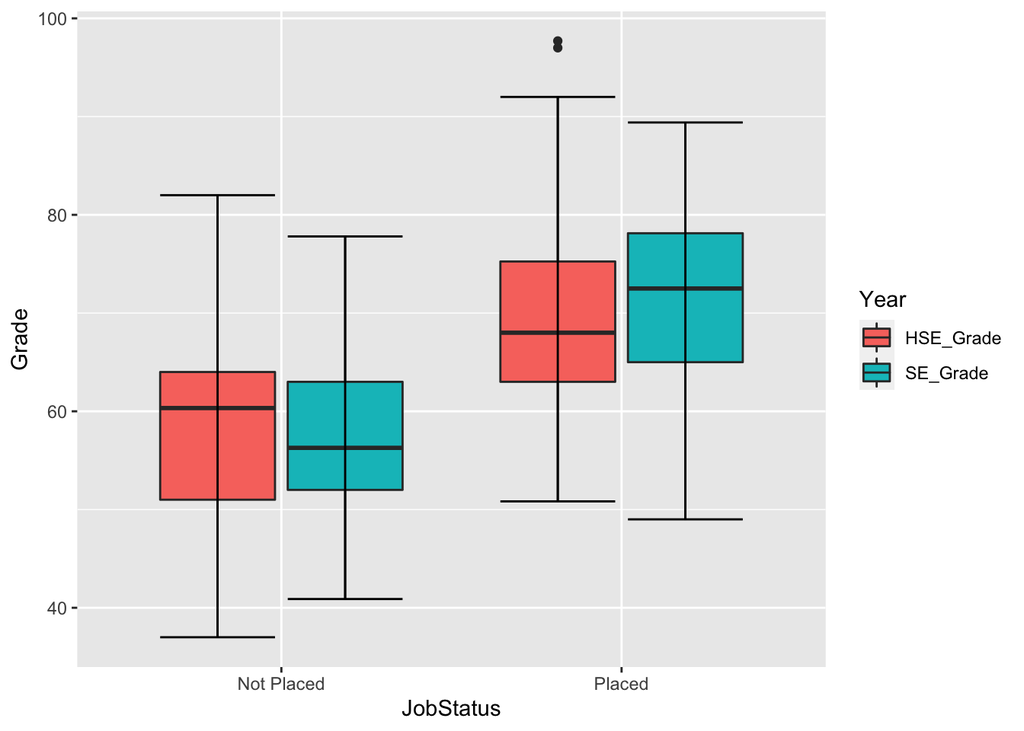

```r
SE_Data = select(PlacementData, "SE_Grade", "JobStatus")
SE_Data = mutate(SE_Data, Year = ifelse(is.na(SE_Grade), NA, "SE_Grade"), Grade = SE_Grade)
SE_Data1 = select(SE_Data, "Grade", "JobStatus", "Year")
HSE_Data = select(PlacementData, "HSE_Grade", "JobStatus")
HSE_Data = mutate(HSE_Data, Year = ifelse(is.na(HSE_Grade), NA, "HSE_Grade"), Grade = HSE_Grade)
HSE_Data1 = select(HSE_Data, "Grade", "JobStatus", "Year")
All_Grades = rbind(SE_Data1, HSE_Data1)
ggplot(All_Grades,aes(x=JobStatus, y=Grade, fill=Year)) +
  geom_boxplot() +
  stat_boxplot(geom = 'errorbar')
```

This graph leads us to believe there is a relationship between secondary education grades and job placement. More statistical analyses will be necessary to positively determine this relationship.

### Q2: What is the effect of undergraduate degree type and MBA specialization on salary?

```r
PlacementData = read_csv("PlacementData.csv")
```

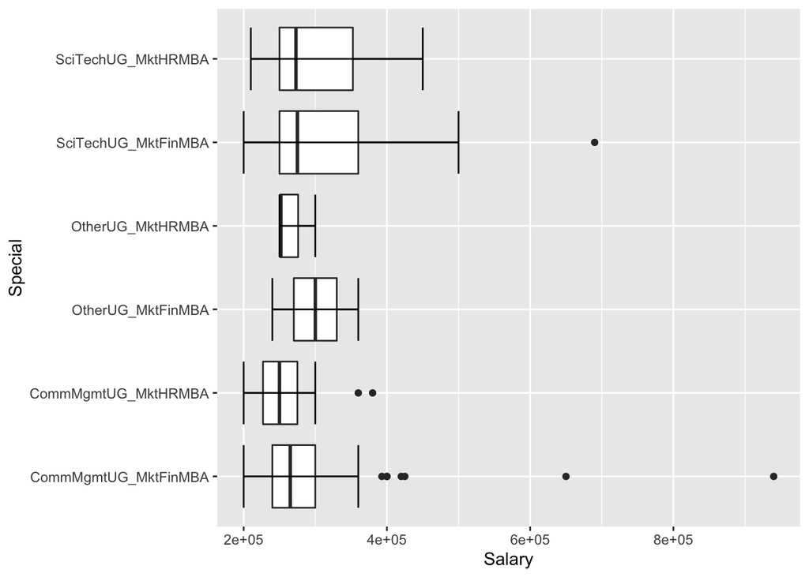

```r
SciTechUG_MktFinMBA = select(PlacementData, UG_Specialization, MBA_Specialization, Salary)
SciTechUG_MktFinMBA = mutate(SciTechUG_MktFinMBA, Special = ifelse(UG_Specialization == "Sci&Tech" & MBA_Specialization == "Mkt&Fin","SciTechUG_MktFinMBA", NA))
SciTechUG_MktHRMBA = select(PlacementData, UG_Specialization, MBA_Specialization, Salary)
SciTechUG_MktHRMBA = mutate(SciTechUG_MktHRMBA, Special = ifelse(UG_Specialization == "Sci&Tech" & MBA_Specialization == "Mkt&HR","SciTechUG_MktHRMBA", NA))
CommMgmtUG_MktFinMBA = select(PlacementData, UG_Specialization, MBA_Specialization, Salary)
CommMgmtUG_MktFinMBA = mutate(CommMgmtUG_MktFinMBA, Special = ifelse(UG_Specialization == "Comm&Mgmt" & MBA_Specialization == "Mkt&Fin","CommMgmtUG_MktFinMBA", NA))
CommMgmtUG_MktHRMBA = select(PlacementData, UG_Specialization, MBA_Specialization, Salary)
CommMgmtUG_MktHRMBA = mutate(CommMgmtUG_MktHRMBA, Special = ifelse(UG_Specialization == "Comm&Mgmt" & MBA_Specialization == "Mkt&HR","CommMgmtUG_MktHRMBA", NA))
OtherUG_MktFinMBA = select(PlacementData, UG_Specialization, MBA_Specialization, Salary)
OtherUG_MktFinMBA = mutate(OtherUG_MktFinMBA, Special = ifelse(UG_Specialization == "Others" & MBA_Specialization == "Mkt&Fin","OtherUG_MktFinMBA", NA))
OtherUG_MktHRMBA = select(PlacementData, UG_Specialization, MBA_Specialization, Salary)
OtherUG_MktHRMBA = mutate(CommMgmtUG_MktHRMBA, Special = ifelse(UG_Specialization == "Others" & MBA_Specialization == "Mkt&HR","OtherUG_MktHRMBA", NA))
Q8Data= rbind(SciTechUG_MktFinMBA, SciTechUG_MktHRMBA, CommMgmtUG_MktFinMBA, CommMgmtUG_MktHRMBA, OtherUG_MktFinMBA, OtherUG_MktHRMBA)
Q8Data1 = na.omit(Q8Data)
ggplot(Q8Data1, aes(x=Special, y=Salary))+
  geom_boxplot() +
  stat_boxplot(geom = 'errorbar') +
  coord_flip()
```

This graph leads us to believe that there is no significant effect of undergraduate degree type and MBA specialization on salary. However, more statistical analyses will be needed to determine if this is true.

# Deliverer: Noah Howell

### Q1: What is the relationship between gender and placement?

```r
data <- read_csv("PlacementData.csv")
head(data)
```

```
## # A tibble: 6 x 15
##   Gender SE_Grade SE_BoE HSE_Grade HSE_BoE HSE_Specializat… UG_Grade
##   <chr>     <dbl> <chr>      <dbl> <chr>   <chr>               <dbl>
## 1 M          67   Others      91   Others  Commerce             58
## 2 M          79.3 Centr…      78.3 Others  Science              77.5
## 3 M          65   Centr…      68   Central Arts                 64
## 4 M          56   Centr…      52   Central Science              52
## 5 M          85.8 Centr…      73.6 Central Commerce             73.3
## 6 M          55   Others      49.8 Others  Science              67.2
## # … with 8 more variables: UG_Specialization <chr>, WorkExp <chr>,
## #   EmploymentTest <dbl>, MBA_Specialization <chr>, MBA_Grade <dbl>,
## #   JobStatus <chr>, Salary <dbl>, WorkExp_1 <lgl>
```

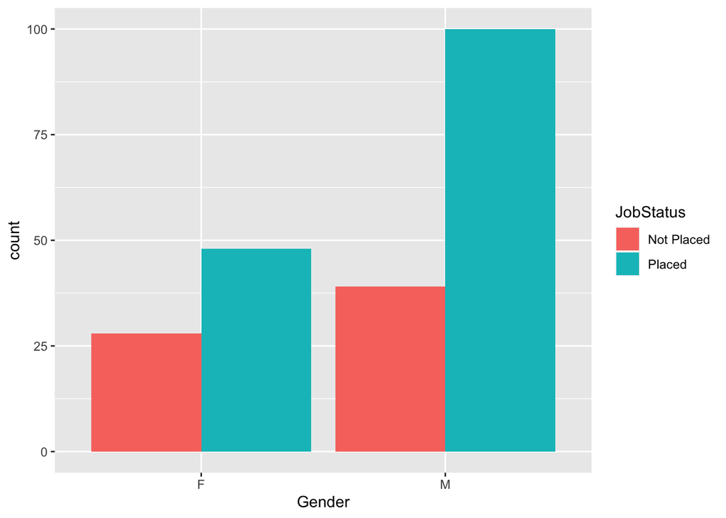

```r
ggplot(data,
       aes(x = Gender,
           fill = JobStatus)) +
  geom_bar(position = "dodge")
```

### Q2: Does work experience have any impact on placement?

```r
data <- read_csv("PlacementData.csv")
head(data)
```

```
## # A tibble: 6 x 15
##   Gender SE_Grade SE_BoE HSE_Grade HSE_BoE HSE_Specializat… UG_Grade
##   <chr>     <dbl> <chr>      <dbl> <chr>   <chr>               <dbl>
## 1 M          67   Others      91   Others  Commerce             58
## 2 M          79.3 Centr…      78.3 Others  Science              77.5
## 3 M          65   Centr…      68   Central Arts                 64
## 4 M          56   Centr…      52   Central Science              52
## 5 M          85.8 Centr…      73.6 Central Commerce             73.3
## 6 M          55   Others      49.8 Others  Science              67.2
## # … with 8 more variables: UG_Specialization <chr>, WorkExp <chr>,
## #   EmploymentTest <dbl>, MBA_Specialization <chr>, MBA_Grade <dbl>,
## #   JobStatus <chr>, Salary <dbl>, WorkExp_1 <lgl>
```

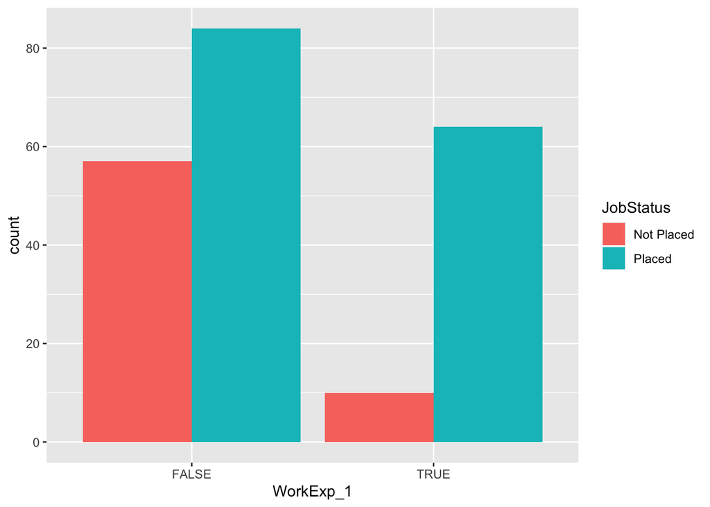

```r
ggplot(data,
       aes(x = WorkExp_1,
           fill = JobStatus)) +
  geom_bar(position = "dodge")
```

# Follow-up Questions

### New Questions Based Off Initial Investigation

- Q1: What is the relationship between MBA specialization and job placement?
- Q2: What determines if individuals are placed?
- Q3: Can we predict the salary of those who are placed?
- Q4: How is the undergraduate experience (degree percentage & field of study) relate to the employability test score?

### Investigation of Follow-up Questions

Our group decided to investigate **Q1**, **Q2** and **Q4** in further detail.

##### Q1

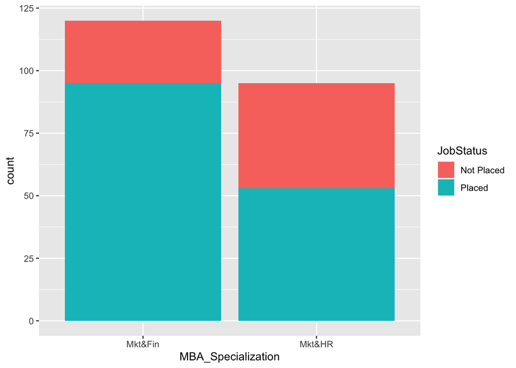

```r
# Q1
PlacementData = read_csv("PlacementData.csv")
attach(PlacementData)
ggplot(PlacementData, aes(x=MBA_Specialization, fill=JobStatus))+
  geom_bar()
```

```r
table <- table(JobStatus, MBA_Specialization)
table
```

```
##             MBA_Specialization
## JobStatus    Mkt&Fin Mkt&HR
##   Not Placed      25     42
##   Placed          95     53
```

```r
prop.table(table)
```

```
##             MBA_Specialization
## JobStatus      Mkt&Fin    Mkt&HR
##   Not Placed 0.1162791 0.1953488
##   Placed     0.4418605 0.2465116
```

```r
chisq.test(table)
```

```
##
##  Pearson's Chi-squared test with Yates' continuity correction
##
## data:  table
## X-squared = 12.44, df = 1, p-value = 0.0004202
```

From the plot given, we can compare MBA specialization with job placement. The results of the chi-squared test indicate that we can reject the null hypothesis (that MBA specialization does not result in any effect on job placement) due to a statistically significant p-value of **0.0004202 (<0.05)**.

##### Q2

```r
#Q2
PlacementData = read_csv("PlacementData2.csv")
JobStatus1 <-ifelse(PlacementData$JobStatus=="Placed", 1, 0)
SE_BoE1 <-ifelse(PlacementData$SE_BoE=="Central", 1, 0)
HSE_BoE1 <-ifelse(PlacementData$HSE_BoE=="Central", 1, 0)
WorkExp2 <-ifelse(PlacementData$WorkExp_1=="TRUE", 1, 0)
Gender1 <-ifelse(PlacementData$Gender=="M", 1, 0)
Reg1Place <- lm(JobStatus1 ~ Gender1+SE_Grade+SE_BoE1+HSE_Grade+HSE_BoE1+UG_Grade+WorkExp2+EmploymentTest+MBA_Grade, data = PlacementData)
summary(Reg1Place)
```

```
##
## Call:
## lm(formula = JobStatus1 ~ Gender1 + SE_Grade + SE_BoE1 + HSE_Grade +
##     HSE_BoE1 + UG_Grade + WorkExp2 + EmploymentTest + MBA_Grade,
##     data = PlacementData)
##
## Residuals:
##     Min      1Q  Median      3Q     Max
## -0.7369 -0.2123 -0.0005  0.2251  0.7279
##
## Coefficients:
##                 Estimate Std. Error t value Pr(>|t|)
## (Intercept)    -0.902266   0.296350  -3.045 0.002635 **
## Gender1         0.074369   0.049939   1.489 0.137968
## SE_Grade        0.018519   0.002700   6.859 8.03e-11 ***
## SE_BoE1        -0.067932   0.057646  -1.178 0.239994
## HSE_Grade       0.011058   0.002533   4.365 2.02e-05 ***
## HSE_BoE1        0.049947   0.057185   0.873 0.383444
## UG_Grade        0.015921   0.003755   4.240 3.39e-05 ***
## WorkExp2        0.177210   0.047867   3.702 0.000275 ***
## EmploymentTest -0.002024   0.001767  -1.146 0.253327
## MBA_Grade      -0.022349   0.004564  -4.897 1.97e-06 ***
## ---
## Signif. codes:  0 '***' 0.001 '**' 0.01 '*' 0.05 '.' 0.1 ' ' 1
##
## Residual standard error: 0.3213 on 205 degrees of freedom
## Multiple R-squared:  0.5411, Adjusted R-squared:  0.521
## F-statistic: 26.86 on 9 and 205 DF,  p-value: < 2.2e-16
```

One flaw of this model is that the R-squared is **0.521**. This is relatively low, as it captures 52.1 percent of the variation within the data. Following this model, we plan on incorporating the other categorical variables into a regression to use all available information to find a better approximation of the marginal effects of determinant. One issue that we need to be wary of is using the R-squared as a measure of how good the next model accounts for variation because the R-squared can be inflated artificially through the addition of new variables. Additionally, we will run tests of goodness-of-fit (AIC and SIC tests) on the final model to see how well the model performs.

##### Q4

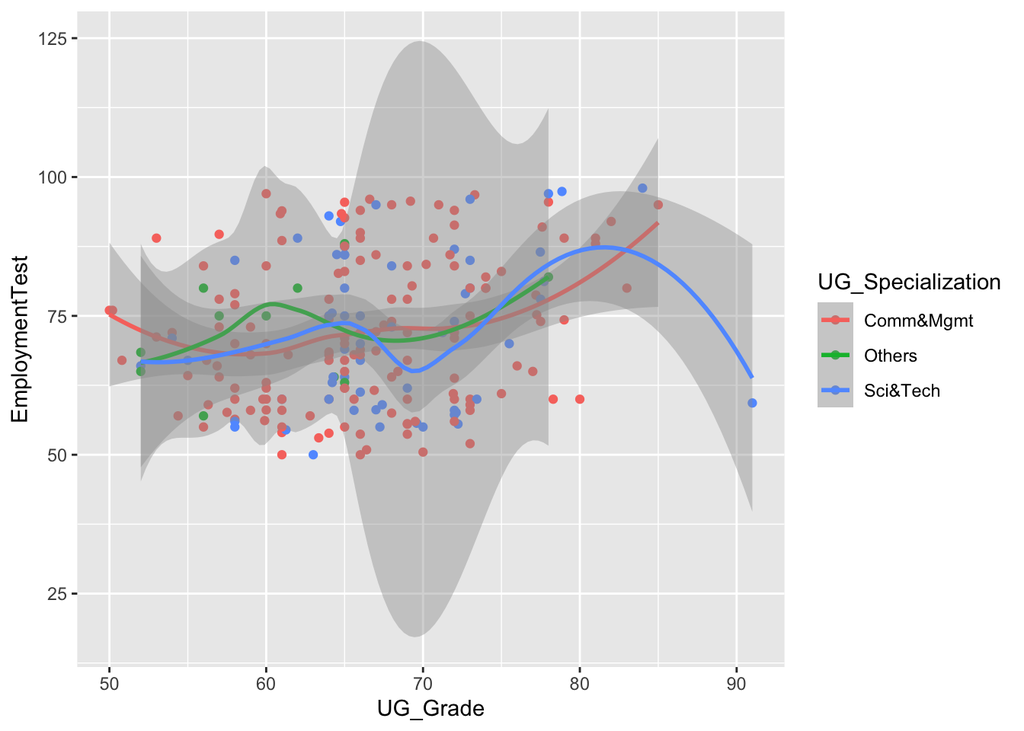

```r
# Q4
ggplot(data=PlacementData, mapping=aes(x=UG_Grade, y=EmploymentTest, color=UG_Specialization))+geom_point()+geom_smooth()
```

```r
without.UG_Specialization = lm(EmploymentTest~UG_Grade, data=PlacementData)
with.UG_Specialization = lm(EmploymentTest~UG_Grade+UG_Specialization, data=PlacementData)
smr.with.UG_Specialization = summary(with.UG_Specialization)
anova.UG_Specialization = anova(without.UG_Specialization, with.UG_Specialization)
smr.coefs = smr.with.UG_Specialization$coefficients
smr.with.UG_Specialization
```

```
##
## Call:
## lm(formula = EmploymentTest ~ UG_Grade + UG_Specialization, data = PlacementData)
##
## Residuals:
##      Min       1Q   Median       3Q      Max
## -23.1120 -10.8683  -0.7521  10.5505  27.6398
##
## Coefficients:
##                           Estimate Std. Error t value Pr(>|t|)
## (Intercept)                43.9692     8.2480   5.331  2.5e-07 ***
## UG_Grade                    0.4232     0.1235   3.426 0.000736 ***
## UG_SpecializationOthers     2.8524     4.1264   0.691 0.490168
## UG_SpecializationSci&Tech  -0.3692     2.0195  -0.183 0.855104
## ---
## Signif. codes:  0 '***' 0.001 '**' 0.01 '*' 0.05 '.' 0.1 ' ' 1
##
## Residual standard error: 13.01 on 211 degrees of freedom
## Multiple R-squared:  0.05286,    Adjusted R-squared:  0.03939
## F-statistic: 3.925 on 3 and 211 DF,  p-value: 0.009368
```

```r
anova.UG_Specialization
```

```
## Analysis of Variance Table
##
## Model 1: EmploymentTest ~ UG_Grade
## Model 2: EmploymentTest ~ UG_Grade + UG_Specialization
##   Res.Df   RSS Df Sum of Sq      F Pr(>F)
## 1    213 35817
## 2    211 35724  2    93.266 0.2754 0.7595
```

From the plot above, we can see that `degree percentage` might have a weak positive relationship with `employability test` score, while the `field of research` does not have a large impact on the overall relationship between `UG_Grade` and `EmploymentTest`. Hence, we can first conclude that `degree percentage` might be a significant factor for predicting `employability test` score, but different `field of study` might not affect the result of prediction from `degree percentage`.

This can be proven by the model summary and anova table, where we first see that the model with both `UG_Grade` and `UG_Specialization` included gives a p-value of $7.3556115\times 10^{-4}$. for `UG_Grade`, which is significant at 5% level. But both levels of `UG_Specialization` are not significant even at **10% level**, indicating that `UG_Specialization` might not be a good predictor for `EmploymentTest`.

We then perform nested test to check if adding `UG_Specialization` would explain more variability of `EmploymentTest`, and the p-value provided is not significant ($0.759515$) at 5% level. Hence, we can conclude that, `field of research` does not explain much extra variability for `EmploymentTest`.

# Summary

- Something that suprised me was the effect of secondary education grades on job placement, and the lack of effect of both degree types on salary.
- For this analysis, we are primarily concerned about the interactions between different variables to determine which interaction terms should be added if we need to build a final model to predict Salary or Job Placement, and the most important observation from above analysis is that the employability test appears to be not closely related to many of these variables and hence might not be a good predictor for both Salary and Job Placement. On the other hand, we also notice some other variables that do have a influence on the subject we are predicting. For instance, from question 1, we decided to investigate the relationship between MBA specialization and job placement because we wanted to see if a certain degree type was more likely to result in an employment opportunity. The figure and table used in this demonstrated that we can reject the null hypothesis (that MBA specialization does not result in any effect on job placement, due to a statistically signficant p-value. This would lead us to investigate further into the relationships between MBA specialization and job placement.